# Coursera Practical Machine Learning Project

Nick Horne

6 July 2018

## Background

Using devices such as Jawbone Up, Nike FuelBand, and Fitbit it is now possible to collect a large amount of data about personal activity relatively inexpensively. These type of devices are part of the quantified self movement - a group of enthusiasts who take measurements about themselves regularly to improve their health, to find patterns in their behavior, or because they are tech geeks. One thing that people regularly do is quantify how much of a particular activity they do, but they rarely quantify how well they do it. In this project, your goal will be to use data from accelerometers on the belt, forearm, arm, and dumbell of 6 participants. They were asked to perform barbell lifts correctly and incorrectly in 5 different ways. More information is available from the website here: http://groupware.les.inf.puc-rio.br/har (see the section on the Weight Lifting Exercise Dataset).

The training data for this project are available here: https://d396qusza40orc.cloudfront.net/predmachlearn/pml-training.csv

The test data are available here: https://d396qusza40orc.cloudfront.net/predmachlearn/pml-testing.csv

The data for this project come from this source: http://groupware.les.inf.puc-rio.br/har. If you use the document you create for this class for any purpose please cite them as they have been very generous in allowing their data to be used for this kind of assignment.

## Exploratory analysis

Load in the test data

```r
training <- read.csv("pml-training.csv")
testing <- read.csv("pml-testing.csv")
```

The classification (classe) is a factor of 5 levels:

```r
levels(training$classe)
```

```
## [1] "A" "B" "C" "D" "E"
```

Reading up on the information provided, class **A** would mean they completed the barbell lifts using the correct technique and the other levels are lifts with common mistakes.

Grab a count of the number of NA variables in each column

```r
na_counts <- sapply(training, function(x) sum(length(which(is.na(x)))))
```

There are 67 columns containing exactly 19216 NA records. We should remove these variables before doing any predictions as it accounts for a large percentage of the recordings we have: 97.93. The same columns are also removed from the test data.

```r
na_vars <- which(na_counts == 19216)
training <- training[-na_vars]
testing <- testing[-na_vars]
```

We can also remove any variables with near zero variance. The same is applied to the testing data.

```r
nsv <- nearZeroVar(training)
training <- training[,-nsv]
testing <- testing[,-nsv]
```

Out of the remaining columns, the first 6 are either time series data or username data. We can remove those columns before continuing. We remove the same columns from the testing data too.

```r
training <- training[,7:dim(training)[2]]
testing <- testing[,7:dim(testing)[2]]
```

We can now see that all our columns are also numerical (except for the classe). Finally we can remove any highly correlated variables.

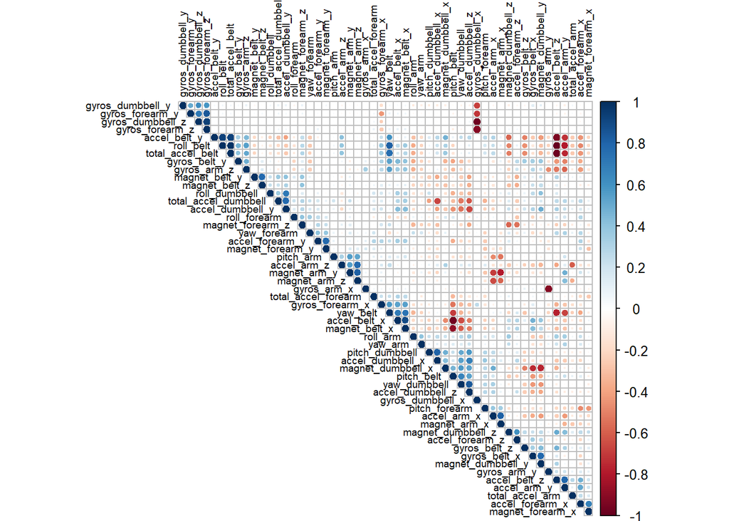

```r
cor_matrix <- cor(training[,1:52]) # Excluding the classe
corrplot(cor_matrix,
         order="hclust",
         type="upper",
         tl.cex = 0.6,
         tl.col = rgb(0, 0, 0))
```

There are a few quite highly correlated variables and we could look at removing them but I have chosen to leave them. We are now left with 53 interesting columns to evaluate.

## Fitting a model

First lets partition the training data into a 60% 40% split as reccomended in the class. I will then look at trying two popular methods to model the data (decision tree and random forest).

```r
set.seed(999)
inTrain <- createDataPartition(training$classe, p=0.60, list=F)
train_data <- training[inTrain, ]
test_data <- training[-inTrain, ]
```

### Decision tree

Use a decision tree to model the data. You may need a magnifying glass for this plot.

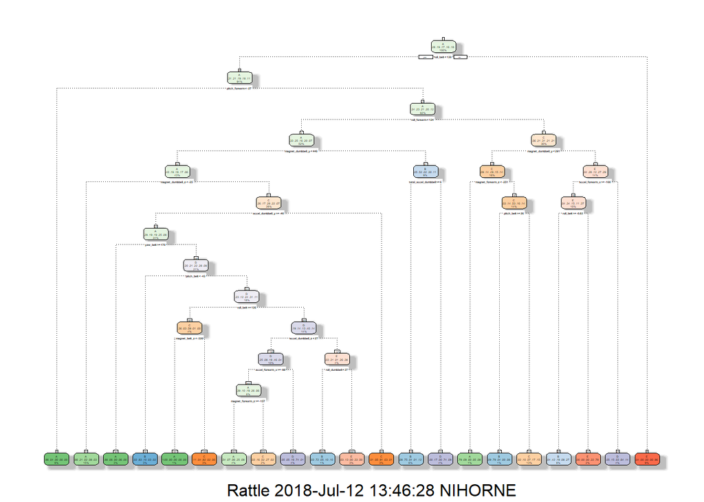

```r
set.seed(1000)
dt_fit <- rpart(classe ~ .,
                  data = train_data,
                  method="class")
fancyRpartPlot(dt_fit)
```

Make a prediction on the test set

```r
dt_prediction <- predict(dt_fit, newdata=test_data, type="class")
dt_confusion_matrix <- confusionMatrix(dt_prediction, test_data$classe)
dt_confusion_matrix
```

```
## Confusion Matrix and Statistics
##
##           Reference
## Prediction    A    B    C    D    E
##          A 2014  332   44  201   62
##          B   65  907  149   85  248
##          C   60  134 1102  235  153
##          D   49  122   73  668   54
##          E   44   23    0   97  925
##
## Overall Statistics
##
##                Accuracy : 0.7158
##                  95% CI : (0.7057, 0.7257)
##     No Information Rate : 0.2845
##     P-Value [Acc > NIR] : < 2.2e-16
##
##                   Kappa : 0.6379
##  Mcnemar's Test P-Value : < 2.2e-16
##
## Statistics by Class:
##
##                      Class: A Class: B Class: C Class: D Class: E
## Sensitivity            0.9023   0.5975   0.8056  0.51944   0.6415
## Specificity            0.8862   0.9136   0.9102  0.95457   0.9744
## Pos Pred Value         0.7591   0.6238   0.6544  0.69151   0.8494
## Neg Pred Value         0.9580   0.9044   0.9568  0.91017   0.9235
## Prevalence             0.2845   0.1935   0.1744  0.16391   0.1838
## Detection Rate         0.2567   0.1156   0.1405  0.08514   0.1179
## Detection Prevalence   0.3381   0.1853   0.2146  0.12312   0.1388
## Balanced Accuracy      0.8943   0.7555   0.8579  0.73701   0.8079
```

This has an accuracy of 0.72

### Random Forest

Using random forest to model the data.

```r
set.seed(1001)
rm_fit <- train(classe ~ .,
                          data=train_data,
                          method="rf",
                          trControl=trainControl(method="cv", number=3, verboseIter=F))
rm_fit$finalModel
```

```
##
## Call:
##  randomForest(x = x, y = y, mtry = param$mtry)
##                Type of random forest: classification
##                      Number of trees: 500
## No. of variables tried at each split: 27
##
##         OOB estimate of  error rate: 0.92%
## Confusion matrix:
##      A    B    C    D    E class.error
## A 3344    3    1    0    0 0.001194743
## B   23 2251    5    0    0 0.012286090
## C    0   17 2028    9    0 0.012658228
## D    0    2   25 1900    3 0.015544041
## E    0    4    7    9 2145 0.009237875
```

Make a prediction on the test set

```r
rf_prediction <- predict(rm_fit, newdata=test_data)
rf_confusion_matrix <- confusionMatrix(rf_prediction, test_data$classe)
rf_confusion_matrix
```

```
## Confusion Matrix and Statistics
##
##           Reference
## Prediction    A    B    C    D    E
##          A 2228   10    0    0    0
##          B    1 1505    5    1    0
##          C    2    2 1361   25    3
##          D    0    1    2 1260    3
##          E    1    0    0    0 1436
##
## Overall Statistics
##
##                Accuracy : 0.9929
##                  95% CI : (0.9907, 0.9946)
##     No Information Rate : 0.2845
##     P-Value [Acc > NIR] : < 2.2e-16
##
##                   Kappa : 0.991
##  Mcnemar's Test P-Value : NA
##
## Statistics by Class:
##
##                      Class: A Class: B Class: C Class: D Class: E
## Sensitivity            0.9982   0.9914   0.9949   0.9798   0.9958
## Specificity            0.9982   0.9989   0.9951   0.9991   0.9998
## Pos Pred Value         0.9955   0.9954   0.9770   0.9953   0.9993
## Neg Pred Value         0.9993   0.9979   0.9989   0.9960   0.9991
## Prevalence             0.2845   0.1935   0.1744   0.1639   0.1838
## Detection Rate         0.2840   0.1918   0.1735   0.1606   0.1830
## Detection Prevalence   0.2852   0.1927   0.1775   0.1614   0.1832
## Balanced Accuracy      0.9982   0.9952   0.9950   0.9894   0.9978
```

This has an accuracy of 0.99

## Final model fit

The random forest model performed much better and so I will use that to perform my final prediction.

```r
final_prediction <- predict(rm_fit, newdata=testing)
final_prediction
```

```
##  [1] B A B A A E D B A A B C B A E E A B B B
## Levels: A B C D E
```